# py_decisionforests_binaryclass_kaggle_tabular_playground_2021oct

### Binary Classification Model for Kaggle Tabular Playground Series October 2021 Using TensorFlow Decision Forests

### November 18, 2021

Template Credit: Adapted from a template made available by Dr. Jason Brownlee of Machine Learning Mastery. [https://machinelearningmastery.com/]

SUMMARY: This project aims to construct a predictive model using various machine learning algorithms and document the end-to-end steps using a template. The Kaggle Tabular Playground October 2021 dataset is a binary classification situation where we attempt to predict one of the two possible outcomes.

INTRODUCTION: Kaggle wants to provide an approachable environment for relatively new people in their data science journey. Since January 2021, they have hosted playground-style competitions on Kaggle with fun but less complex, tabular datasets. The dataset used for this competition is synthetic but based on a real dataset and generated using a CTGAN. The original dataset deals with predicting the biological response of molecules given various chemical properties. Although the features are anonymized, they have properties relating to real-world features.

CONCLUSION: In this iteration, the TensorFlow Decision Forests model appeared to be a suitable algorithm for modeling this dataset.

Dataset Used: Kaggle Tabular Playground 2021 October Data Set

Dataset ML Model: Binary classification with numerical and categorical attributes

Dataset Reference: https://www.kaggle.com/c/tabular-playground-series-oct-2021

One potential source of performance benchmark: https://www.kaggle.com/c/tabular-playground-series-oct-2021/leaderboard

1. Prepare Environment
2. Summarize and Visualize Data
3. Train and Evaluate Models
4. Fine-tune and Improve Models
5. Finalize Model and Make Predictions

## Task 1 - Prepare Environment

```python
# Install the necessary packages for Colab
!pip install python-dotenv PyMySQL boto3
!pip install tensorflow_decision_forests
```

[output not shown]

```python
!pip install wurlitzer
```

```python
# Retrieve the GPU information from Colab
gpu_info = !nvidia-smi
gpu_info = '\n'.join(gpu_info)
if gpu_info.find('failed') >= 0:
    print('Select the Runtime → "Change runtime type" menu to enable a GPU accelerator, ')
    print('and then re-execute this cell.')
else:
    print(gpu_info)
```

```
Select the Runtime → "Change runtime type" menu to enable a GPU accelerator,
and then re-execute this cell.
```

```python
# Retrieve the memory configuration from Colab
from psutil import virtual_memory
ram_gb = virtual_memory().total / 1e9
print('Your runtime has {:.1f} gigabytes of available RAM\n'.format(ram_gb))

if ram_gb < 20:
    print('To enable a high-RAM runtime, select the Runtime → "Change runtime type"')
    print('menu, and then select High-RAM in the Runtime shape dropdown. Then, ')
    print('re-execute this cell.')
else:
    print('You are using a high-RAM runtime!')
```

```
Your runtime has 54.8 gigabytes of available RAM

You are using a high-RAM runtime!
```

```python
# Retrieve the CPU information
ncpu = !nproc
print("The number of available CPUs is:", ncpu[0])
```

```
The number of available CPUs is: 8
```

```python
# Set up the parent directory location for loading the dotenv files
from dotenv import load_dotenv
from google.colab import drive
drive.mount('/content/gdrive')
gdrivePrefix = '/content/gdrive/My Drive/Colab_Downloads/'
env_path = '/content/gdrive/My Drive/Colab Notebooks/'
dotenv_path = env_path + "python_script.env"
load_dotenv(dotenv_path=dotenv_path)
```

```
True
```

### 1.a) Load libraries and modules

```python
# Set the random seed number for reproducible results
RNG_SEED = 888
```

```python
import random
random.seed(RNG_SEED)
import numpy as np
np.random.seed(RNG_SEED)
import pandas as pd
import seaborn as sns
import matplotlib.pyplot as plt
import os
import sys
import math
from datetime import datetime
import boto3
from sklearn import preprocessing
from sklearn.model_selection import train_test_split
from sklearn.model_selection import RepeatedKFold
from sklearn.pipeline import Pipeline
from sklearn import compose
from sklearn import impute
import tensorflow as tf
tf.random.set_seed(RNG_SEED)
from tensorflow import keras
import tensorflow_decision_forests as tfdf
```

```
WARNING:root:Failure to load the custom c++ tensorflow ops. This error is likely caused the version of TensorFlow and TensorFlow Decision Forests are not compatible.
WARNING:root:TF Parameter Server distributed training not available.
```

```python
try:
  from wurlitzer import sys_pipes
except:
  from colabtools.googlelog import CaptureLog as sys_pipes

from IPython.core.magic import register_line_magic
from IPython.display import Javascript
```

### 1.b) Set up the controlling parameters and functions

```python
# Begin the timer for the script processing
start_time_script = datetime.now()

# Set up the number of CPU cores available for multi-thread processing
N_JOBS = 1

# Set up the flag to stop sending progress emails (setting to True will send status emails!)
NOTIFY_STATUS = True

# Set the percentage sizes for splitting the dataset
TEST_SET_RATIO = 0.2
VAL_SET_RATIO = 0.1

# Set the number of folds for cross validation
N_FOLDS = 5
N_ITERATIONS = 1

# Set various default modeling parameters
DEFAULT_LOSS = 'binary_crossentropy'
DEFAULT_METRICS = ["accuracy", tf.keras.metrics.AUC()]
DEFAULT_OPTIMIZER = tf.keras.optimizers.Adam(learning_rate=0.00005)
DEFAULT_INITIALIZER = tf.keras.initializers.RandomNormal(seed=RNG_SEED)
CLASSIFIER_ACTIVATION = 'sigmoid'
MAX_EPOCHS = 50
BATCH_SIZE = 32

# Define the directory locations and file names
TRAIN_DATASET = 'train.csv'
TEST_DATASET = 'test.csv'

# Check the number of GPUs accessible through TensorFlow
print('Num GPUs Available:', len(tf.config.list_physical_devices('GPU')))

# Print out the TensorFlow version for confirmation
print('TensorFlow version:', tf.__version__)

# Check the version of TensorFlow Decision Forests
print("Found TensorFlow Decision Forests v" + tfdf.__version__)
```

```
Num GPUs Available: 0
TensorFlow version: 2.7.0
Found TensorFlow Decision Forests v0.2.1
```

```python
# Set up the email notification function
def status_notify(msg_text):
    access_key = os.environ.get('SNS_ACCESS_KEY')
    secret_key = os.environ.get('SNS_SECRET_KEY')
    aws_region = os.environ.get('SNS_AWS_REGION')
    topic_arn = os.environ.get('SNS_TOPIC_ARN')
    if (access_key is None) or (secret_key is None) or (aws_region is None):
        sys.exit("Incomplete notification setup info. Script Processing Aborted!!!")
    sns = boto3.client('sns', aws_access_key_id=access_key, aws_secret_access_key=secret_key, region_name=aws_region)
    response = sns.publish(TopicArn=topic_arn, Message=msg_text)
    if response['ResponseMetadata']['HTTPStatusCode'] != 200 :
        print('Status notification not OK with HTTP status code:', response['ResponseMetadata']['HTTPStatusCode'])
```

```python
# Reset the random number generators
def reset_random(x=RNG_SEED):
    random.seed(x)
    np.random.seed(x)
    tf.random.set_seed(x)
```

```python
if NOTIFY_STATUS: status_notify("Task 1 - Prepare Environment has begun! " + datetime.now().strftime('%a %B %d, %Y %I:%M:%S %p'))
```

### 1.c) Load dataset

```python
if not os.path.exists(TRAIN_DATASET):
    !wget https://dainesanalytics.com/datasets/kaggle-tabular-playground-2021oct/train.csv
```

```
--2021-11-15 17:23:03--  https://dainesanalytics.com/datasets/kaggle-tabular-playground-2021oct/train.csv
Resolving dainesanalytics.com (dainesanalytics.com)... 54.230.15.96, 54.230.15.86, 54.230.15.67, ...
Connecting to dainesanalytics.com (dainesanalytics.com)|54.230.15.96|:443... connected.
HTTP request sent, awaiting response... 200 OK
Length: 2324353215 (2.2G) [text/csv]
Saving to: ‘train.csv’

train.csv           100%[===================>]   2.16G  45.5MB/s    in 72s

2021-11-15 17:24:15 (30.8 MB/s) - ‘train.csv’ saved [2324353215/2324353215]
```

```python
df_dataset_import = pd.read_csv(TRAIN_DATASET, index_col=False)

# Take a peek at the dataframe after import
print(df_dataset_import.head())
```

```
   id        f0        f1        f2        f3  ...  f281  f282  f283  f284  target
0   0  0.205979  0.410993  0.176775  0.223581  ...     0     0     0     0       1
1   1  0.181004  0.473119  0.011734  0.213657  ...     0     0     0     0       1
2   2  0.182583  0.307431  0.325950  0.207116  ...     0     0     0     0       1
3   3  0.180240  0.494592  0.008367  0.223580  ...     0     0     0     0       1
4   4  0.177172  0.495513  0.014263  0.548819  ...     0     0     1     0       1

[5 rows x 287 columns]
```

```python
df_dataset_import.info(verbose=True)
```

```
<class 'pandas.core.frame.DataFrame'>
RangeIndex: 1000000 entries, 0 to 999999
Data columns (total 287 columns):
 #   Column  Dtype
---  ------  -----
 0   id      int64
 1   f0      float64
 2   f1      float64
 3   f2      float64
 4   f3      float64
 5   f4      float64
 6   f5      float64
 7   f6      float64
 8   f7      float64
 9   f8      float64
```

[output cut: 279 more lines]

```python
print(df_dataset_import.describe())
```

```
                   id              f0  ...           f284          target
count  1000000.000000  1000000.000000  ...  1000000.00000  1000000.000000
mean    499999.500000        0.214334  ...        0.15468        0.500485
std     288675.278933        0.053320  ...        0.36160        0.500000
min          0.000000        0.041790  ...        0.00000        0.000000
25%     249999.750000        0.181676  ...        0.00000        0.000000
50%     499999.500000        0.204498  ...        0.00000        1.000000
75%     749999.250000        0.229684  ...        0.00000        1.000000
max     999999.000000        1.000000  ...        1.00000        1.000000

[8 rows x 287 columns]
```

```python
print(df_dataset_import.isnull().sum())
print('Total number of NaN in the dataframe: ', df_dataset_import.isnull().sum().sum())
```

```
id        0
f0        0
f1        0
f2        0
f3        0
         ..
f281      0
f282      0
f283      0
f284      0
target    0
Length: 287, dtype: int64
Total number of NaN in the dataframe:  0
```

### 1.d) Data Cleaning

```python
# Dropping features
df_dataset_import.drop(columns=['id'], inplace=True)

# Take a peek at the dataframe after cleaning
print(df_dataset_import.head())
```

```
         f0        f1        f2        f3  ...  f282  f283  f284  target
0  0.205979  0.410993  0.176775  0.223581  ...     0     0     0       1
1  0.181004  0.473119  0.011734  0.213657  ...     0     0     0       1
2  0.182583  0.307431  0.325950  0.207116  ...     0     0     0       1
3  0.180240  0.494592  0.008367  0.223580  ...     0     0     0       1
4  0.177172  0.495513  0.014263  0.548819  ...     0     1     0       1

[5 rows x 286 columns]
```

```python
df_dataset_import.info(verbose=True)
```

```
<class 'pandas.core.frame.DataFrame'>
RangeIndex: 1000000 entries, 0 to 999999
Data columns (total 286 columns):
 #   Column  Dtype
---  ------  -----
 0   f0      float64
 1   f1      float64
 2   f2      float64
 3   f3      float64
 4   f4      float64
 5   f5      float64
 6   f6      float64
 7   f7      float64
 8   f8      float64
 9   f9      float64
```

[output cut: 278 more lines]

```python
print(df_dataset_import.describe())
```

```
                   f0              f1  ...           f284          target
count  1000000.000000  1000000.000000  ...  1000000.00000  1000000.000000
mean         0.214334        0.460218  ...        0.15468        0.500485
std          0.053320        0.101316  ...        0.36160        0.500000
min          0.041790        0.022016  ...        0.00000        0.000000
25%          0.181676        0.389215  ...        0.00000        0.000000
50%          0.204498        0.453893  ...        0.00000        1.000000
75%          0.229684        0.526023  ...        0.00000        1.000000
max          1.000000        0.959019  ...        1.00000        1.000000

[8 rows x 286 columns]
```

```python
print(df_dataset_import.isnull().sum())
print('Total number of NaN in the dataframe: ', df_dataset_import.isnull().sum().sum())
```

```
f0        0
f1        0
f2        0
f3        0
f4        0
         ..
f281      0
f282      0
f283      0
f284      0
target    0
Length: 286, dtype: int64
Total number of NaN in the dataframe:  0
```

### 1.e) Splitting Data into Sets

```python
# Use variable total_column_count to hold the number of columns in the dataframe
total_column_count = len(df_dataset_import.columns)

# Set up variable total_feature_count for the total number of attribute columns
total_feature_count = total_column_count-1

# We create attribute-only and target-only datasets (df_features_train and df_target_train)
df_target_train = df_dataset_import['target']
df_features_train = df_dataset_import.drop(['target'], axis=1)

print("df_dataset_import.shape: {} df_features_train.shape: {} df_target_train.shape: {}".format(df_dataset_import.shape, df_features_train.shape, df_target_train.shape))
```

```
df_dataset_import.shape: (1000000, 286) df_features_train.shape: (1000000, 285) df_target_train.shape: (1000000,)
```

### 1.f) Set up the parameters for data visualization

```python
# Set up the number of row and columns for visualization display. display_rows * display_columns should be >= total_feature_count
display_columns = 4
if total_feature_count % display_columns == 0 :
    display_rows = total_feature_count // display_columns
else :
    display_rows = (total_feature_count // display_columns) + 1

# Set figure width to display the data visualization plots
fig_size = plt.rcParams["figure.figsize"]
fig_size[0] = display_columns * 4
fig_size[1] = display_rows * 4
plt.rcParams["figure.figsize"] = fig_size
```

```python
if NOTIFY_STATUS: status_notify("Task 1 - Prepare Environment completed! "+datetime.now().strftime('%a %B %d, %Y %I:%M:%S %p'))
```

## Task 2 - Summarize and Visualize Data

```python
if NOTIFY_STATUS: status_notify("Task 2 - Summarize and Visualize Data has begun! "+datetime.now().strftime('%a %B %d, %Y %I:%M:%S %p'))
```

[figure not shown]

```python
# Histograms for each attribute
df_features_train.plot(kind='hist', subplots=True, layout=(display_rows, display_columns))
plt.show()
```

[figure not shown]

```python
# Box and Whisker plot for each attribute
df_features_train.plot(kind='box', subplots=True, layout=(display_rows, display_columns))
plt.show()
```

```python
# # Correlation matrix
# fig = plt.figure(figsize=(20, 20))
# correlations = df_features_train.corr(method='pearson')
# sns.heatmap(correlations, annot=True, cmap=plt.cm.PuBu)
# plt.show()
```

```python
if NOTIFY_STATUS: status_notify("Task 2 - Summarize and Visualize Data completed! "+datetime.now().strftime('%a %B %d, %Y %I:%M:%S %p'))
```

## Task 3 - Train and Evaluate Models

```python
if NOTIFY_STATUS: status_notify("Task 3 - Train and Evaluate Models has begun! "+datetime.now().strftime('%a %B %d, %Y %I:%M:%S %p'))
```

### 3.a) Splitting Data into Training and Validation Sets

```python
# Split the data further into training and validation datasets
df_dataset_train, df_dataset_valid = train_test_split(df_dataset_import, test_size=VAL_SET_RATIO, random_state=RNG_SEED)
print("df_dataset_train.shape: {} df_dataset_valid.shape: {}".format(df_dataset_train.shape, df_dataset_valid.shape))
```

```
df_dataset_train.shape: (900000, 286) df_dataset_valid.shape: (100000, 286)
```

```python
# Finalize the training and validation datasets for the modeling activities
tfds_train = tfdf.keras.pd_dataframe_to_tf_dataset(df_dataset_train, label='target', task=tfdf.keras.Task.CLASSIFICATION)
tfds_valid = tfdf.keras.pd_dataframe_to_tf_dataset(df_dataset_valid, label='target', task=tfdf.keras.Task.CLASSIFICATION)
```

### 3.b) Train and Evaluate the Random Forest Model

```python
# Define the baseline model for benchmarking
start_time_module = datetime.now()
if NOTIFY_STATUS: status_notify("TFDF Random Forest modeling has begun! "+datetime.now().strftime('%a %B %d, %Y %I:%M:%S %p'))
model_1 = tfdf.keras.RandomForestModel(task=tfdf.keras.Task.CLASSIFICATION)

# Optionally, add evaluation metrics.
model_1.compile(metrics=DEFAULT_METRICS)

# Train the model.
# "sys_pipes" is optional. It enables the display of the training logs.
with sys_pipes():
    model_1.fit(x=tfds_train)
print ('Model training time:', (datetime.now() - start_time_module), '\n')
if NOTIFY_STATUS: status_notify("TFDF Random Forest modeling completed! "+datetime.now().strftime('%a %B %d, %Y %I:%M:%S %p'))
```

[output not shown]

[output cut: 698 more lines]

```
[INFO random_forest.cc:628] Training of tree  281/300 (tree index:281) done accuracy:0.759098 logloss:0.495175
[INFO random_forest.cc:628] Training of tree  284/300 (tree index:283) done accuracy:0.759056 logloss:0.495177
[INFO random_forest.cc:628] Training of tree  287/300 (tree index:286) done accuracy:0.759088 logloss:0.495135
[INFO random_forest.cc:628] Training of tree  289/300 (tree index:287) done accuracy:0.759131 logloss:0.495108
[INFO random_forest.cc:628] Training of tree  290/300 (tree index:289) done accuracy:0.759148 logloss:0.495134
[INFO random_forest.cc:628] Training of tree  295/300 (tree index:294) done accuracy:0.759141 logloss:0.495078
[INFO random_forest.cc:628] Training of tree  299/300 (tree index:296) done accuracy:0.759106 logloss:0.494998
[INFO random_forest.cc:628] Training of tree  300/300 (tree index:299) done accuracy:0.759064 logloss:0.494983
[INFO random_forest.cc:696] Final OOB metrics: accuracy:0.759064 logloss:0.494983
[INFO kernel.cc:828] Export model in log directory: /tmp/tmpl6fs6ezl
[INFO kernel.cc:836] Save model in resources
[INFO kernel.cc:988] Loading model from path
[INFO decision_forest.cc:590] Model loaded with 300 root(s), 4785548 node(s), and 285 input feature(s).
[INFO abstract_model.cc:993] Engine "RandomForestOptPred" built
[INFO kernel.cc:848] Use fast generic engine
```

```
Model training time: 0:30:40.230929
```

```python
tfdf.model_plotter.plot_model_in_colab(model_1)
```

```python
model_1.make_inspector().evaluation()
```

```
Evaluation(num_examples=900000, accuracy=0.7590644444444444, loss=0.49498282011195344, rmse=None, ndcg=None, aucs=None)
```

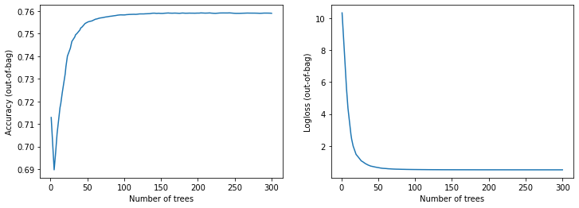

```python
logs = model_1.make_inspector().training_logs()

plt.figure(figsize=(12, 4))

plt.subplot(1, 2, 1)
plt.plot([log.num_trees for log in logs], [log.evaluation.accuracy for log in logs])
plt.xlabel("Number of trees")
plt.ylabel("Accuracy (out-of-bag)")

plt.subplot(1, 2, 2)
plt.plot([log.num_trees for log in logs], [log.evaluation.loss for log in logs])
plt.xlabel("Number of trees")
plt.ylabel("Logloss (out-of-bag)")

plt.show()
```

```python
evaluation = model_1.evaluate(tfds_valid, return_dict=True)
print()

for name, value in evaluation.items():
  print(f"{name}: {value:.4f}")
```

[output not shown]

### 3.c) Train and Evaluate the Decision Trees Model

```python
# Define the baseline model for benchmarking
start_time_module = datetime.now()
if NOTIFY_STATUS: status_notify("TFDF Decision Trees modeling has begun! "+datetime.now().strftime('%a %B %d, %Y %I:%M:%S %p'))
model_2 = tfdf.keras.CartModel(task=tfdf.keras.Task.CLASSIFICATION)

# Optionally, add evaluation metrics.
model_2.compile(
    metrics=DEFAULT_METRICS)

# Train the model.
# "sys_pipes" is optional. It enables the display of the training logs.
with sys_pipes():
    model_2.fit(x=tfds_train)
print ('Model training time:', (datetime.now() - start_time_module), '\n')
if NOTIFY_STATUS: status_notify("TFDF Decision Trees modeling completed! "+datetime.now().strftime('%a %B %d, %Y %I:%M:%S %p'))
```

[output not shown]

[output cut: 587 more lines]

```
  validation_ratio: 0.1
}

[INFO kernel.cc:790] Deployment config:
num_threads: 6

[INFO kernel.cc:817] Train model
[INFO cart.cc:174] Training CART on 900000 example(s) and 285 feature(s).
[INFO cart.cc:375] 17035 nodes before pruning. 3945 nodes after pruning.
[INFO kernel.cc:828] Export model in log directory: /tmp/tmplyp72h6t
[INFO kernel.cc:836] Save model in resources
[INFO kernel.cc:988] Loading model from path
[INFO decision_forest.cc:590] Model loaded with 1 root(s), 3945 node(s), and 252 input feature(s).
[INFO abstract_model.cc:993] Engine "RandomForestOptPred" built
[INFO kernel.cc:848] Use fast generic engine
```

```
Model training time: 0:06:13.119379
```

```python
tfdf.model_plotter.plot_model_in_colab(model_2)
```

```python
model_2.make_inspector().evaluation()
```

```python
evaluation = model_2.evaluate(tfds_valid, return_dict=True)
print()

for name, value in evaluation.items():
  print(f"{name}: {value:.4f}")
```

```
loss: 0.0000
accuracy: 0.6513
auc: 0.7828
```

### 3.d) Train and Evaluate the Gradient Boosted Trees Model

```python
# Define the baseline model for benchmarking
start_time_module = datetime.now()
if NOTIFY_STATUS: status_notify("TFDF Gradient Boosted Treees modeling has begun! "+datetime.now().strftime('%a %B %d, %Y %I:%M:%S %p'))
model_3 = tfdf.keras.GradientBoostedTreesModel(task=tfdf.keras.Task.CLASSIFICATION)

# Optionally, add evaluation metrics.
model_3.compile(
    metrics=DEFAULT_METRICS)

# Train the model.
# "sys_pipes" is optional. It enables the display of the training logs.
with sys_pipes():
    model_3.fit(x=tfds_train)
print ('Model training time:', (datetime.now() - start_time_module), '\n')
if NOTIFY_STATUS: status_notify("TFDF Gradient Boosted Trees modeling completed! "+datetime.now().strftime('%a %B %d, %Y %I:%M:%S %p'))
```

[output not shown]

[output cut: 684 more lines]

```
[INFO gradient_boosted_trees.cc:1428] 	num-trees:274 train-loss:0.917603 train-accuracy:0.776223 valid-loss:0.944892 valid-accuracy:0.768083
[INFO gradient_boosted_trees.cc:1428] 	num-trees:278 train-loss:0.916999 train-accuracy:0.776365 valid-loss:0.944710 valid-accuracy:0.767950
[INFO gradient_boosted_trees.cc:1428] 	num-trees:282 train-loss:0.916424 train-accuracy:0.776512 valid-loss:0.944463 valid-accuracy:0.767617
[INFO gradient_boosted_trees.cc:1428] 	num-trees:286 train-loss:0.915835 train-accuracy:0.776655 valid-loss:0.944282 valid-accuracy:0.767683
[INFO gradient_boosted_trees.cc:1428] 	num-trees:290 train-loss:0.915254 train-accuracy:0.776796 valid-loss:0.944041 valid-accuracy:0.767628
[INFO gradient_boosted_trees.cc:1428] 	num-trees:294 train-loss:0.914689 train-accuracy:0.776937 valid-loss:0.943847 valid-accuracy:0.767561
[INFO gradient_boosted_trees.cc:1428] 	num-trees:298 train-loss:0.914108 train-accuracy:0.777069 valid-loss:0.943710 valid-accuracy:0.767572
[INFO gradient_boosted_trees.cc:1426] 	num-trees:300 train-loss:0.913833 train-accuracy:0.777128 valid-loss:0.943612 valid-accuracy:0.767528
[INFO gradient_boosted_trees.cc:229] Truncates the model to 300 tree(s) i.e. 300  iteration(s).
[INFO gradient_boosted_trees.cc:263] Final model num-trees:300 valid-loss:0.943612 valid-accuracy:0.767528
[INFO kernel.cc:828] Export model in log directory: /tmp/tmpfzeyu47s
[INFO kernel.cc:836] Save model in resources
[INFO kernel.cc:988] Loading model from path
[INFO abstract_model.cc:993] Engine "GradientBoostedTreesQuickScorerExtended" built
[INFO kernel.cc:848] Use fast generic engine
```

```
Model training time: 0:47:17.729295
```

```python
tfdf.model_plotter.plot_model_in_colab(model_3)
```

```python
model_3.make_inspector().evaluation()
```

```
Evaluation(num_examples=None, accuracy=0.7675280570983887, loss=0.9436118602752686, rmse=None, ndcg=None, aucs=None)
```

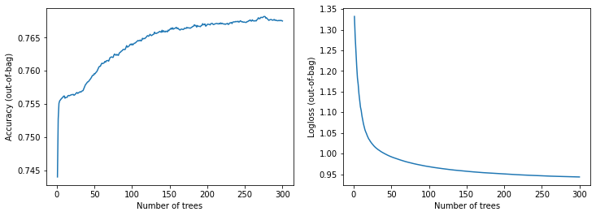

```python
logs = model_3.make_inspector().training_logs()

plt.figure(figsize=(12, 4))

plt.subplot(1, 2, 1)
plt.plot([log.num_trees for log in logs], [log.evaluation.accuracy for log in logs])
plt.xlabel("Number of trees")
plt.ylabel("Accuracy (out-of-bag)")

plt.subplot(1, 2, 2)
plt.plot([log.num_trees for log in logs], [log.evaluation.loss for log in logs])
plt.xlabel("Number of trees")
plt.ylabel("Logloss (out-of-bag)")

plt.show()
```

```python
evaluation = model_3.evaluate(tfds_valid, return_dict=True)
print()

for name, value in evaluation.items():
  print(f"{name}: {value:.4f}")
```

```
loss: 0.0000
accuracy: 0.7684
auc: 0.8086
```

```python
if NOTIFY_STATUS: status_notify("Task 3 - Train and Evaluate Models completed! "+datetime.now().strftime('%a %B %d, %Y %I:%M:%S %p'))
```

## Task 4 - Fine-tune and Improve Models

```python
if NOTIFY_STATUS: status_notify("Task 4 - Fine-tune and Improve Models has begun! "+datetime.now().strftime('%a %B %d, %Y %I:%M:%S %p'))
```

```python
for num_trees in [300, 500, 750, 1000]:
    # Define the baseline model for benchmarking
    start_time_module = datetime.now()
    model_tune = tfdf.keras.RandomForestModel(num_trees=num_trees, task=tfdf.keras.Task.CLASSIFICATION)

    # Optionally, add evaluation metrics.
    model_tune.compile(metrics=DEFAULT_METRICS)

    # Train the model.
    model_tune.fit(x=tfds_train, verbose=False)

    evaluation = model_tune.evaluate(tfds_valid, return_dict=True)
    print()

    for name, value in evaluation.items():
        print(f"{name}: {value:.4f}")
    print ('Model optimization time:', (datetime.now() - start_time_module), '\n')
```

```
loss: 0.0000
accuracy: 0.7595
auc: 0.8177
Model optimization time: 0:30:22.396864

WARNING:tensorflow:5 out of the last 5 calls to <function CoreModel.make_predict_function.<locals>.predict_function_trained at 0x7fe259bc50e0> triggered tf.function retracing. Tracing is expensive and the excessive number of tracings could be due to (1) creating @tf.function repeatedly in a loop, (2…
```

[output not shown]

```
loss: 0.0000
accuracy: 0.7594
auc: 0.8231
Model optimization time: 0:46:18.618391

WARNING:tensorflow:6 out of the last 6 calls to <function CoreModel.make_predict_function.<locals>.predict_function_trained at 0x7fe1c0dba0e0> triggered tf.function retracing. Tracing is expensive and the excessive number of tracings could be due to (1) creating @tf.function repeatedly in a loop, (2…
```

[output not shown]

```
loss: 0.0000
accuracy: 0.7595
auc: 0.8267
Model optimization time: 1:06:15.582153


loss: 0.0000
accuracy: 0.7595
auc: 0.8293
Model optimization time: 1:25:50.172400
```

```python
if NOTIFY_STATUS: status_notify("Task 4 - Fine-tune and Improve Models completed! "+datetime.now().strftime('%a %B %d, %Y %I:%M:%S %p'))
```

## Task 5 - Finalize Model and Make Predictions

```python
if NOTIFY_STATUS: status_notify("Task 5 - Finalize Model and Make Predictions has begun! "+datetime.now().strftime('%a %B %d, %Y %I:%M:%S %p'))
```

### 5.a) Train the Final Model

```python
# Finalize the training and validation datasets for the modeling activities
tfds_train = tfdf.keras.pd_dataframe_to_tf_dataset(df_dataset_import, label='target')
```

```python
# Define the baseline model for benchmarking
start_time_module = datetime.now()
if NOTIFY_STATUS: status_notify("The final TFDF model training has begun! "+datetime.now().strftime('%a %B %d, %Y %I:%M:%S %p'))
final_model = tfdf.keras.RandomForestModel(num_trees=1000, task=tfdf.keras.Task.CLASSIFICATION)

# Optionally, add evaluation metrics.
final_model.compile(
    metrics=DEFAULT_METRICS)

# Train the model.
# "sys_pipes" is optional. It enables the display of the training logs.
with sys_pipes():
    final_model.fit(x=tfds_train)
print ('Model training time:', (datetime.now() - start_time_module), '\n')
if NOTIFY_STATUS: status_notify("The final TFDF model training completed! "+datetime.now().strftime('%a %B %d, %Y %I:%M:%S %p'))
```

[output not shown]

[output cut: 969 more lines]

```
[INFO random_forest.cc:628] Training of tree  981/1000 (tree index:981) done accuracy:0.758785 logloss:0.492773
[INFO random_forest.cc:628] Training of tree  984/1000 (tree index:983) done accuracy:0.758788 logloss:0.492736
[INFO random_forest.cc:628] Training of tree  985/1000 (tree index:986) done accuracy:0.758791 logloss:0.492749
[INFO random_forest.cc:628] Training of tree  988/1000 (tree index:987) done accuracy:0.758789 logloss:0.492758
[INFO random_forest.cc:628] Training of tree  991/1000 (tree index:990) done accuracy:0.758796 logloss:0.492734
[INFO random_forest.cc:628] Training of tree  996/1000 (tree index:995) done accuracy:0.758787 logloss:0.492698
[INFO random_forest.cc:628] Training of tree  999/1000 (tree index:999) done accuracy:0.758808 logloss:0.492689
[INFO random_forest.cc:628] Training of tree  1000/1000 (tree index:998) done accuracy:0.758802 logloss:0.492698
[INFO random_forest.cc:696] Final OOB metrics: accuracy:0.758802 logloss:0.492698
[INFO kernel.cc:828] Export model in log directory: /tmp/tmpotp0e3uf
[INFO kernel.cc:836] Save model in resources
[INFO kernel.cc:988] Loading model from path
[INFO decision_forest.cc:590] Model loaded with 1000 root(s), 16746530 node(s), and 285 input feature(s).
[INFO abstract_model.cc:993] Engine "RandomForestOptPred" built
[INFO kernel.cc:848] Use fast generic engine
```

```
Model training time: 1:38:00.614506
```

```python
final_model.summary()
```

[output not shown]

[output cut: 2744 more lines]

```
	trees: 963, Out-of-bag evaluation: accuracy:0.758813 logloss:0.492807
	trees: 965, Out-of-bag evaluation: accuracy:0.758809 logloss:0.49282
	trees: 968, Out-of-bag evaluation: accuracy:0.758806 logloss:0.492807
	trees: 970, Out-of-bag evaluation: accuracy:0.758819 logloss:0.49278
	trees: 972, Out-of-bag evaluation: accuracy:0.758807 logloss:0.492791
	trees: 975, Out-of-bag evaluation: accuracy:0.758819 logloss:0.492766
	trees: 978, Out-of-bag evaluation: accuracy:0.758806 logloss:0.492756
	trees: 981, Out-of-bag evaluation: accuracy:0.758785 logloss:0.492773
	trees: 984, Out-of-bag evaluation: accuracy:0.758788 logloss:0.492736
	trees: 985, Out-of-bag evaluation: accuracy:0.758791 logloss:0.492749
	trees: 988, Out-of-bag evaluation: accuracy:0.758789 logloss:0.492758
	trees: 991, Out-of-bag evaluation: accuracy:0.758796 logloss:0.492734
	trees: 996, Out-of-bag evaluation: accuracy:0.758787 logloss:0.492698
	trees: 999, Out-of-bag evaluation: accuracy:0.758808 logloss:0.492689
	trees: 1000, Out-of-bag evaluation: accuracy:0.758802 logloss:0.492698
```

```python
tfdf.model_plotter.plot_model_in_colab(final_model)
```

```python
final_model.make_inspector().evaluation()
```

```
Evaluation(num_examples=1000000, accuracy=0.758802, loss=0.4926982762662396, rmse=None, ndcg=None, aucs=None)
```

```python
evaluation = final_model.evaluate(tfds_valid, return_dict=True)
print()

for name, value in evaluation.items():
  print(f"{name}: {value:.4f}")
```

```
loss: 0.0000
accuracy: 0.7735
auc: 0.8383
```

### 5.b) Load Test Dataset and Prepare the Submission File

```python
if not os.path.exists(TEST_DATASET):
    !wget https://dainesanalytics.com/datasets/kaggle-tabular-playground-2021oct/test.csv
```

```
--2021-11-16 00:24:21--  https://dainesanalytics.com/datasets/kaggle-tabular-playground-2021oct/test.csv
Resolving dainesanalytics.com (dainesanalytics.com)... 54.230.15.67, 54.230.15.70, 54.230.15.86, ...
Connecting to dainesanalytics.com (dainesanalytics.com)|54.230.15.67|:443... connected.
HTTP request sent, awaiting response... 200 OK
Length: 1162300847 (1.1G) [text/csv]
Saving to: ‘test.csv’

test.csv            100%[===================>]   1.08G  55.9MB/s    in 27s

2021-11-16 00:24:48 (41.2 MB/s) - ‘test.csv’ saved [1162300847/1162300847]
```

```python
df_features_test = pd.read_csv(TEST_DATASET, index_col=False)

# Take a peek at the dataframe after import
print(df_features_test.head())
```

```
        id        f0        f1        f2  ...  f281  f282  f283  f284
0  1000000  0.178216  0.435617  0.010230  ...     1     1     1     0
1  1000001  0.181250  0.476455  0.022413  ...     0     0     0     0
2  1000002  0.159721  0.451202  0.259649  ...     1     0     0     0
3  1000003  0.182424  0.520976  0.095344  ...     1     0     0     0
4  1000004  0.229329  0.336513  0.023511  ...     0     1     0     0

[5 rows x 286 columns]
```

```python
df_kaggle_submission = pd.DataFrame()
df_kaggle_submission['id'] = df_features_test['id']
print(df_kaggle_submission.head())
```

```
        id
0  1000000
1  1000001
2  1000002
3  1000003
4  1000004
```

```python
# Dropping features
df_features_test.drop(columns=['id'], inplace=True)

# Take a peek at the dataframe after cleaning
print(df_features_test.head())
```

```
         f0        f1        f2        f3  ...  f281  f282  f283  f284
0  0.178216  0.435617  0.010230  0.202074  ...     1     1     1     0
1  0.181250  0.476455  0.022413  0.283146  ...     0     0     0     0
2  0.159721  0.451202  0.259649  0.365274  ...     1     0     0     0
3  0.182424  0.520976  0.095344  0.327742  ...     1     0     0     0
4  0.229329  0.336513  0.023511  0.300913  ...     0     1     0     0

[5 rows x 285 columns]
```

```python
# Finalize the test dataset for the prediction activities
tfds_test = tfdf.keras.pd_dataframe_to_tf_dataset(df_features_test)
```

```python
# Make batched predictions
test_predictions = final_model.predict(tfds_test)
print(test_predictions)
```

```
[[0.7059945 ]
 [0.24900033]
 [0.8589925 ]
 ...
 [0.36599883]
 [0.60799575]
 [0.3599989 ]]
```

```python
df_kaggle_submission['target'] = test_predictions
print(df_kaggle_submission.head())
```

```
        id    target
0  1000000  0.705994
1  1000001  0.249000
2  1000002  0.858993
3  1000003  0.764994
4  1000004  0.178000
```

```python
submission_file = df_kaggle_submission.to_csv(header=True, index=False)
filename = 'submission_' + datetime.now().strftime('%Y%m%d-%H%M') + '.csv'
with open(filename, 'w') as f:
    f.write(submission_file)
    print('Completed writing output file: ' + filename)
```

```
Completed writing output file: submission_20211116-0032.csv
```

```python
if NOTIFY_STATUS: status_notify("Task 5 - Finalize Model and Make Predictions completed! "+datetime.now().strftime('%a %B %d, %Y %I:%M:%S %p'))
```

```python
print ('Total time for the script:',(datetime.now() - start_time_script))
```

```
Total time for the script: 7:09:52.493530
```